# PS2

Annie Gao

Worked with Riddhima Mishra and Di Yang.

# 1.2

## 1

```r
flights %>%
  count(carrier) %>%
  arrange(desc(carrier))
```

```
## # A tibble: 16 x 2
##    carrier     n
##      <chr> <int>
##  1      YV   601
##  2      WN 12275
##  3      VX  5162
##  4      US 20536
##  5      UA 58665
##  6      OO    32
##  7      MQ 26397
##  8      HA   342
##  9      FL  3260
## 10      F9   685
## 11      EV 54173
## 12      DL 48110
## 13      B6 54635
## 14      AS   714
## 15      AA 32729
## 16      9E 18460
```

## 2

```r
#1
flights %>%
  group_by(carrier) %>%
  summarize(count = n(),
            avgarrdelay = mean(arr_delay, na.rm = TRUE))
```

```
## # A tibble: 16 x 3
##    carrier count avgarrdelay
##      <chr> <int>       <dbl>
##  1      9E 18460   7.3796692
##  2      AA 32729   0.3642909
##  3      AS   714  -9.9308886
##  4      B6 54635   9.4579733
##  5      DL 48110   1.6443409
##  6      EV 54173  15.7964311
##  7      F9   685  21.9207048
##  8      FL  3260  20.1159055
##  9      HA   342  -6.9152047
## 10      MQ 26397  10.7747334
## 11      OO    32  11.9310345
## 12      UA 58665   3.5580111
## 13      US 20536   2.1295951
## 14      VX  5162   1.7644644
## 15      WN 12275   9.6491199
## 16      YV   601  15.5569853
```

```r
#2
flights %>%
  group_by(carrier) %>%
  summarize(count = n(),
            medarrdelay = median(arr_delay, na.rm = TRUE))
```

```
## # A tibble: 16 x 3
##    carrier count medarrdelay
##      <chr> <int>       <dbl>
##  1      9E 18460          -7
##  2      AA 32729          -9
##  3      AS   714         -17
##  4      B6 54635          -3
##  5      DL 48110          -8
##  6      EV 54173          -1
##  7      F9   685           6
##  8      FL  3260           5
##  9      HA   342         -13
## 10      MQ 26397          -1
## 11      OO    32          -7
## 12      UA 58665          -6
## 13      US 20536          -6
## 14      VX  5162          -9
## 15      WN 12275          -3
## 16      YV   601          -2
```

```r
#3
flights %>%
  group_by(carrier) %>%
  summarize(count = n(),
            minarrdelay = min(arr_delay, na.rm = TRUE))
```

```
## # A tibble: 16 x 3
##    carrier count minarrdelay
##      <chr> <int>       <dbl>
##  1      9E 18460         -68
##  2      AA 32729         -75
##  3      AS   714         -74
##  4      B6 54635         -71
##  5      DL 48110         -71
##  6      EV 54173         -62
##  7      F9   685         -47
##  8      FL  3260         -44
##  9      HA   342         -70
## 10      MQ 26397         -53
## 11      OO    32         -26
## 12      UA 58665         -75
## 13      US 20536         -70
## 14      VX  5162         -86
## 15      WN 12275         -58
## 16      YV   601         -46
```

```r
#4
flights %>%
  group_by(carrier) %>%
  summarize(count = n(),
            maxarrdelay = max(arr_delay, na.rm = TRUE))
```

```
## # A tibble: 16 x 3
##    carrier count maxarrdelay
##      <chr> <int>       <dbl>
##  1      9E 18460         744
##  2      AA 32729        1007
##  3      AS   714         198
##  4      B6 54635         497
##  5      DL 48110         931
##  6      EV 54173         577
##  7      F9   685         834
##  8      FL  3260         572
##  9      HA   342        1272
## 10      MQ 26397        1127
## 11      OO    32         157
## 12      UA 58665         455
## 13      US 20536         492
## 14      VX  5162         676
## 15      WN 12275         453
## 16      YV   601         381
```

```r
#5
flights %>%
  group_by(carrier) %>%
  summarize(count = n(),
            iqrarrdelay = IQR(arr_delay, na.rm = TRUE))
```

```
## # A tibble: 16 x 3
##    carrier count iqrarrdelay
##      <chr> <int>       <dbl>
##  1      9E 18460       36.00
##  2      AA 32729       29.00
##  3      AS   714       34.00
##  4      B6 54635       31.00
##  5      DL 48110       28.00
##  6      EV 54173       40.00
##  7      F9   685       40.00
##  8      FL  3260       31.00
##  9      HA   342       30.50
## 10      MQ 26397       31.00
## 11      OO    32       22.00
## 12      UA 58665       30.00
## 13      US 20536       23.00
## 14      VX  5162       31.00
## 15      WN 12275       30.00
## 16      YV   601       40.25
```

I found 5 measures of arrival delays using the mean, median, minimum, maximum, and IQR, grouped by airline.

## 3

Normally, passengers would think departure delay is more important. However, we should care about arrival delay because even if a flight is delayed in departure, it could still make up time in the air to ensure it arrives on time. The problem occurs when a flight does not arrive on time, not necessarily that it was delayed in taking off.

## 4

```r
not_cancelled <- filter(flights, !is.na(dep_delay) | !is.na(arr_delay))

not_cancelled %>% count(dest) #want to replicate this
```

```
## # A tibble: 104 x 2
##     dest     n
##    <chr> <int>
##  1   ABQ   254
##  2   ACK   265
##  3   ALB   419
##  4   ANC     8
##  5   ATL 16898
##  6   AUS  2418
##  7   AVL   263
##  8   BDL   412
##  9   BGR   360
## 10   BHM   272
## # ... with 94 more rows
```

```r
# different approach
not_cancelled %>%
  group_by(dest) %>%
  summarise(n = n())
```

```
## # A tibble: 104 x 2
##     dest     n
##    <chr> <int>
##  1   ABQ   254
##  2   ACK   265
##  3   ALB   419
##  4   ANC     8
##  5   ATL 16898
##  6   AUS  2418
##  7   AVL   263
##  8   BDL   412
##  9   BGR   360
## 10   BHM   272
## # ... with 94 more rows
```

```r
not_cancelled %>% count(tailnum, wt = distance) #want to replicate this
```

```
## # A tibble: 4,037 x 2
##    tailnum      n
##      <chr>  <dbl>
##  1  D942DN   3418
##  2  N0EGMQ 240626
##  3  N10156 110389
##  4  N102UW  25722
##  5  N103US  24619
##  6  N104UW  25157
##  7  N10575 141475
##  8  N105UW  23618
##  9  N107US  21677
## 10  N108UW  32070
## # ... with 4,027 more rows
```

```r
#different approach
not_cancelled %>%
  group_by(tailnum) %>%
  summarize(n = sum(distance))
```

```
## # A tibble: 4,037 x 2
##    tailnum      n
##      <chr>  <dbl>
##  1  D942DN   3418
##  2  N0EGMQ 240626
##  3  N10156 110389
##  4  N102UW  25722
##  5  N103US  24619
##  6  N104UW  25157
##  7  N10575 141475
##  8  N105UW  23618
##  9  N107US  21677
## 10  N108UW  32070
## # ... with 4,027 more rows
```

## 5

Definition of cancelled flights as (is.na(dep_delay) | is.na(arr_delay) is suboptimal because they could be redundant. (is.na(dep_delay)) and (is.na(arr_delay)) might be capturing the same flights that were cancelled. We would not see arrival delay if there was an NA in the departure delay for that light, and vice versa. Since we’re examining arrival delay, that column would be more important.

## 6

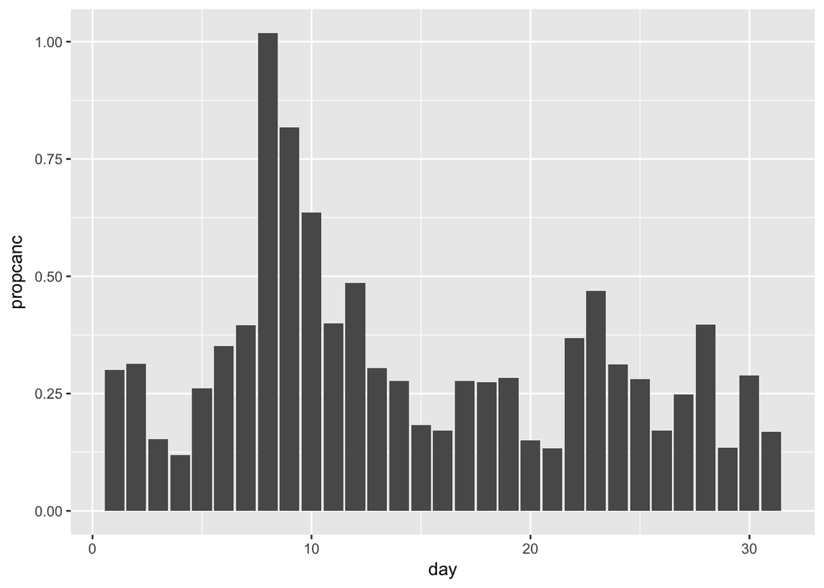

```r
propplot <- flights %>%
  group_by(month, day) %>%
  summarise(propcanc = mean(is.na(arr_delay)),
            avgdelay = mean(arr_delay, na.rm = TRUE))

ggplot(propplot) +
  geom_histogram(mapping = aes(x = day, y = propcanc),
                 stat = "identity")
```

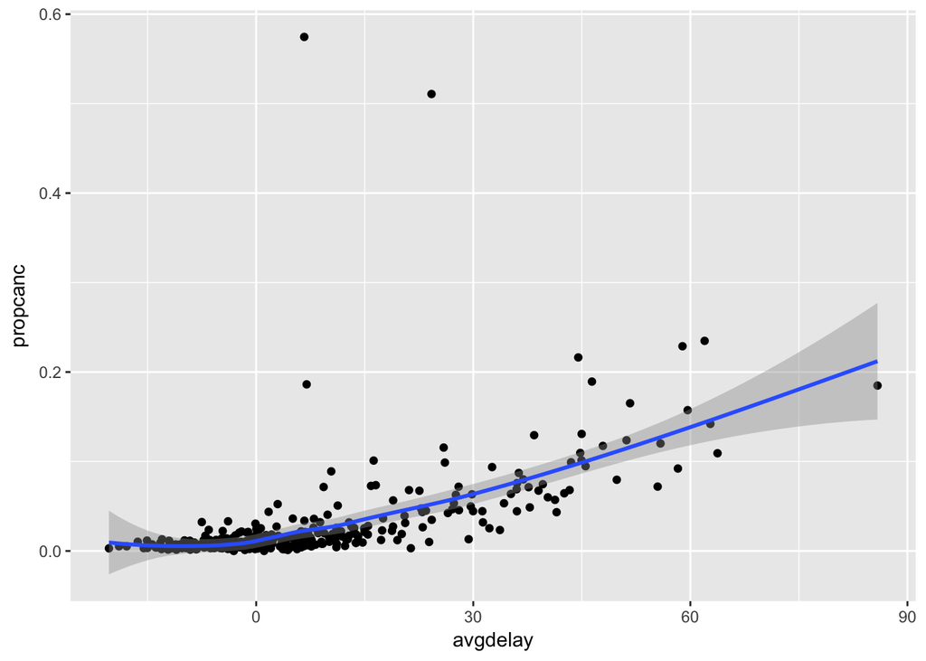

```r
ggplot(propplot, aes(x=avgdelay, y=propcanc)) +
  geom_point() +
  geom_smooth()
```

From the histogram, we see that cancellation proportions are highest around the 10th of the month. The second plot shows that there is a pattern between the average delay and the proportion of cancelled flights. They seem to trace out the same trajectory.

## 7

```r
flights %>%
  group_by(carrier) %>%
  summarise(avgar_delay = mean((arr_delay), na.rm = TRUE)) %>%
  arrange(desc(avgar_delay)) %>%
  mutate(rank = rank(desc(avgar_delay)))
```

```
## # A tibble: 16 x 3
##    carrier avgar_delay  rank
##      <chr>       <dbl> <dbl>
##  1      F9  21.9207048     1
##  2      FL  20.1159055     2
##  3      EV  15.7964311     3
##  4      YV  15.5569853     4
##  5      OO  11.9310345     5
##  6      MQ  10.7747334     6
##  7      WN   9.6491199     7
##  8      B6   9.4579733     8
##  9      9E   7.3796692     9
## 10      UA   3.5580111    10
## 11      US   2.1295951    11
## 12      VX   1.7644644    12
## 13      DL   1.6443409    13
## 14      AA   0.3642909    14
## 15      HA  -6.9152047    15
## 16      AS  -9.9308886    16
```

The output is grouped by carrier with average arrival delays by carrier and ranked with 1 being the longest arrival delay. F9 is the carrier ranked as the worst by average delays.

## 8

```r
flights %>%
  filter(origin == "LGA"| origin == "JFK") %>%
  group_by(dest) %>%
  summarise(avgar_delay = mean((arr_delay), na.rm = TRUE)) %>%
  arrange(desc(avgar_delay)) %>%
  mutate(rank = rank(desc(avgar_delay)))
```

```
## # A tibble: 94 x 3
##     dest avgar_delay  rank
##    <chr>       <dbl> <dbl>
##  1   CAK    19.69834     1
##  2   CAE    19.66667     2
##  3   EGE    18.53465     3
##  4   MHT    17.52778     4
##  5   BHM    16.87732     5
##  6   CVG    16.27475     6
##  7   TVC    15.97260     7
##  8   MSN    15.28910     8
##  9   CRW    14.67164     9
## 10   SBN    14.50000    10
## # ... with 84 more rows
```

The output is first filtered for just flights originating from JFK or LGA and grouped with average arrival delays by destination and ranked in the same way as above. CAK is the worst destination.

# 1.3

## 1

```r
flights %>%
  group_by(tailnum) %>%
  summarise(total = sum(arr_delay, na.rm = TRUE),
            appearfreq = n()) %>%
  arrange(desc(total))
```

```
## # A tibble: 4,044 x 3
##    tailnum total appearfreq
##      <chr> <dbl>      <int>
##  1  N15910  7317        280
##  2  N15980  7134        316
##  3  N16919  6904        251
##  4  N228JB  6778        388
##  5  N14998  6087        230
##  6  N192JB  5810        319
##  7  N292JB  5804        322
##  8  N12921  5788        280
##  9  N13958  5620        259
## 10  N10575  5566        289
## # ... with 4,034 more rows
```

N15910 has the most number of arrival delays with a total of 7317 minutes. There were 280 planes delayed every time it appeared in the dataset.

## 2

```r
flights %>%
  group_by(time_hour) %>%
  summarise(total = sum(arr_delay, na.rm = TRUE)) %>%
  arrange(desc(total))
```

```
## # A tibble: 6,936 x 2
##              time_hour total
##                 <dttm> <dbl>
##  1 2013-07-28 19:00:00  8961
##  2 2013-07-22 17:00:00  8757
##  3 2013-07-22 16:00:00  8568
##  4 2013-03-18 19:00:00  8532
##  5 2013-06-27 18:00:00  8527
##  6 2013-04-19 19:00:00  8466
##  7 2013-08-08 17:00:00  8236
##  8 2013-07-07 17:00:00  8169
##  9 2013-07-10 15:00:00  8163
## 10 2013-06-24 15:00:00  7994
## # ... with 6,926 more rows
```

## 3

```r
flights %>%
  group_by(dest) %>%
  summarise(total = sum(arr_delay, na.rm = TRUE)) %>%
  arrange(desc(total))
```

```
## # A tibble: 105 x 2
##     dest  total
##    <chr>  <dbl>
##  1   ATL 190260
##  2   CLT 100645
##  3   ORD  97352
##  4   FLL  96153
##  5   DCA  82609
##  6   RDU  78107
##  7   MCO  76185
##  8   IAD  74631
##  9   BNA  71867
## 10   DEN  61700
## # ... with 95 more rows
```

```r
#total minutes of delay by destination

flights %>%
  group_by(dest) %>%
  mutate(total = sum(arr_delay, na.rm = TRUE)) %>%
  ungroup() %>%
  mutate(prop = (arr_delay/total)) %>%
  select(dep_delay, total, prop)
```

```
## # A tibble: 336,776 x 3
##    dep_delay  total          prop
##        <dbl>  <dbl>         <dbl>
##  1         2  30046  3.661053e-04
##  2         4  30046  6.656460e-04
##  3         2   3467  9.518316e-03
##  4        -1   7322 -2.458345e-03
##  5        -6 190260 -1.313991e-04
##  6        -4  97352  1.232640e-04
##  7        -5  96153  1.976017e-04
##  8        -3  74631 -1.875896e-04
##  9        -3  76185 -1.050075e-04
## 10        -2  97352  8.217602e-05
## # ... with 336,766 more rows
```

ATL, CLT, and ORD are the three destinations with the highest arrival delays. The second line of code gives each flight’s proportion of delay to total delay to that destination.

## 4

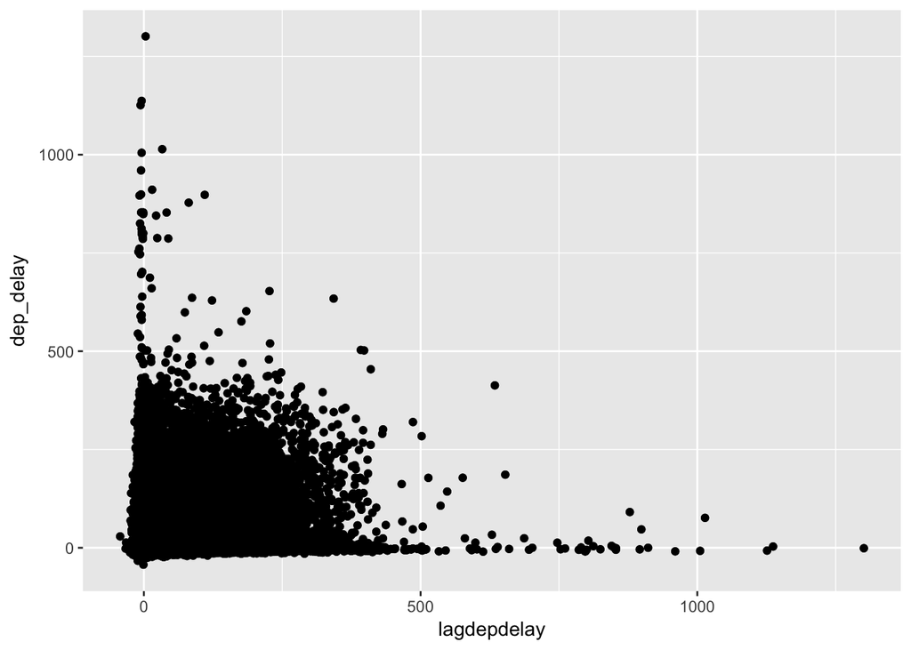

```r
flights %>%
  group_by(dest) %>%
  mutate(lagdepdelay = lag(dep_delay)) %>%
  ggplot(mapping = aes(x = lagdepdelay, y = dep_delay)) +
  geom_point() +
  geom_jitter()
```

It’s unclear if there is a relationship between the delay of a flight and the delay of one immediately preceeding. There is a lot of bunching in the 500 min delay area but this could just be due to lots of flights tending to be delayed by 0-500 minutes and it might not have anything to do with the delay of the preceeding flight. We see this also in that there are also flights that took off on time while the flight before it was delayed.

## 5

```r
flights %>%
  group_by(dest) %>%
  mutate(flightspeed = distance/air_time) %>%
  arrange(desc(flightspeed)) %>%
  select(dest, origin, air_time, flightspeed)
```

```
## # A tibble: 336,776 x 4
## # Groups:   dest [105]
##     dest origin air_time flightspeed
##    <chr>  <chr>    <dbl>       <dbl>
##  1   ATL    LGA       65   11.723077
##  2   MSP    EWR       93   10.838710
##  3   GSP    EWR       55   10.800000
##  4   BNA    EWR       70   10.685714
##  5   PBI    LGA      105    9.857143
##  6   SJU    JFK      170    9.400000
##  7   SJU    JFK      172    9.290698
##  8   STT    JFK      175    9.274286
##  9   SJU    JFK      173    9.236994
## 10   SJU    JFK      173    9.236994
## # ... with 336,766 more rows
```

Flights to ATL, MSP, GSP, and BNA from LGA and EWR had the fastest flightspeeds and really low air_time. Normally, planes travel at approximately 9.6 miles per minute. Since flightspeed is calculated in minutes, the top 4 flight speeds are relatively fast, but they also don’t seem to be faster enough to be recording errors.

## 6

```r
flights %>%
  group_by(dest) %>%
  filter(n_distinct(carrier)>=2) %>%
  select(dest, carrier, everything())
```

```
## # A tibble: 325,397 x 19
## # Groups:   dest [76]
##     dest carrier  year month   day dep_time sched_dep_time dep_delay
##    <chr>   <chr> <int> <int> <int>    <int>          <int>     <dbl>
##  1   IAH      UA  2013     1     1      517            515         2
##  2   IAH      UA  2013     1     1      533            529         4
##  3   MIA      AA  2013     1     1      542            540         2
##  4   BQN      B6  2013     1     1      544            545        -1
##  5   ATL      DL  2013     1     1      554            600        -6
##  6   ORD      UA  2013     1     1      554            558        -4
##  7   FLL      B6  2013     1     1      555            600        -5
##  8   IAD      EV  2013     1     1      557            600        -3
##  9   MCO      B6  2013     1     1      557            600        -3
## 10   ORD      AA  2013     1     1      558            600        -2
## # ... with 325,387 more rows, and 11 more variables: arr_time <int>,
## #   sched_arr_time <int>, arr_delay <dbl>, flight <int>, tailnum <chr>,
## #   origin <chr>, air_time <dbl>, distance <dbl>, hour <dbl>,
## #   minute <dbl>, time_hour <dttm>
```

These are all the destinations that are flown by at least two carriers.

## 7

```r
flights %>%
    group_by(tailnum) %>%
    mutate(index = row_number()) %>%
    filter(arr_delay > 60) %>%
    summarize(countsbfdelay = first(index) - 1)
```

```
## # A tibble: 3,371 x 2
##    tailnum countsbfdelay
##      <chr>         <dbl>
##  1  D942DN             0
##  2  N0EGMQ             0
##  3  N10156             9
##  4  N102UW            33
##  5  N104UW             6
##  6  N10575             0
##  7  N105UW            34
##  8  N107US            29
##  9  N108UW             9
## 10  N109UW            15
## # ... with 3,361 more rows
```

This gives the number of flights grouped by tail number that occurred before the first delay of more than an hour that day.

# 1.4

## 1

```r
diamonds %>%
  summarise(sd_price = sd(price),
            iqr_price = IQR(price),
            mean_price = mean(price),
            median_price = median(price))
```

```
## # A tibble: 1 x 4
##   sd_price iqr_price mean_price median_price
##      <dbl>     <dbl>      <dbl>        <dbl>
## 1  3989.44   4374.25     3932.8         2401
```

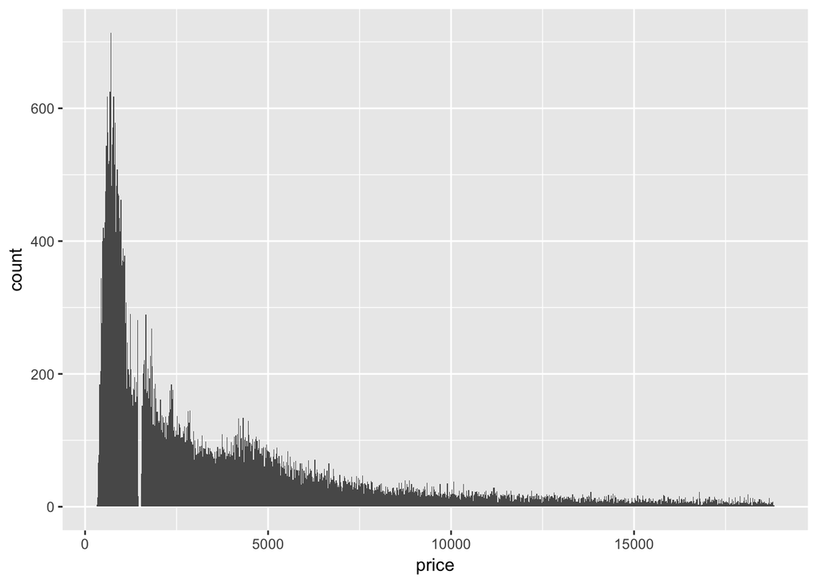

```r
ggplot(diamonds) +
  geom_histogram(mapping = aes(x = price), binwidth = 20)
```

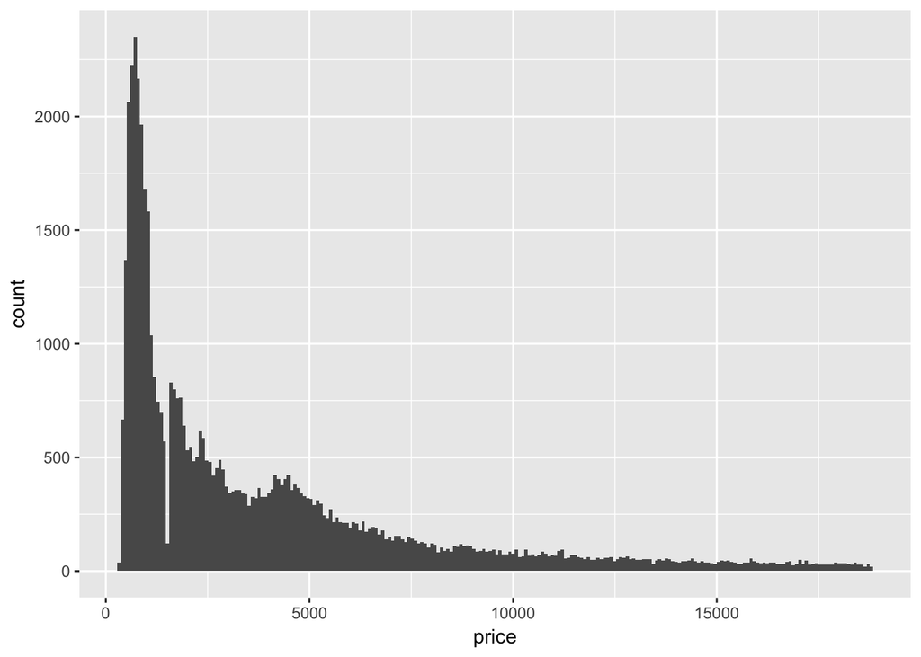

```r
ggplot(diamonds) +
  geom_histogram(mapping = aes(x = price), binwidth = 80)
```

There are more diamonds in the lower price ranges and fewer diamonds as the price increases. In looking at a histogram of diamond prices, we see a break in the price near the high $1000 point. It’s unusual to see that there aren’t diamonds at a specific price in the high $1000s. A larger bin specification would not show the price break clearly.

## 2

```r
diamonds %>% count(carat == 0.99)
```

```
## # A tibble: 2 x 2
##   `carat == 0.99`     n
##             <lgl> <int>
## 1           FALSE 53917
## 2            TRUE    23
```

```r
diamonds %>% count(carat == 1)
```

```
## # A tibble: 2 x 2
##   `carat == 1`     n
##          <lgl> <int>
## 1        FALSE 52382
## 2         TRUE  1558
```

There are 23 diamonds that are 0.99 carats and 1558 diamonds that are 1 carat. There aren’t many .99 diamonds because people might just want to buy a 1 carat diamond instead since it’s not going to be any distinguishably different from a 0.99 carat diamond.

## 3

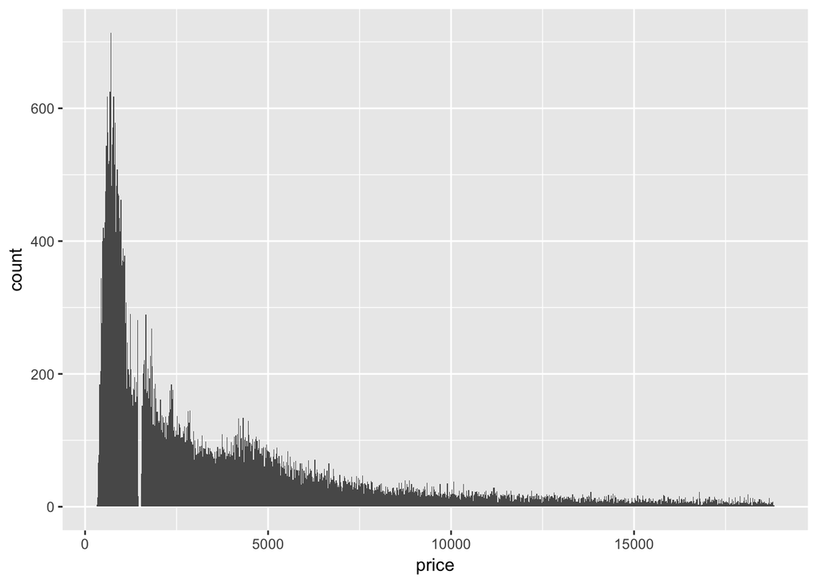

```r
ggplot(diamonds) +
  geom_histogram(mapping = aes(x = price),
                 binwidth = 20)
```

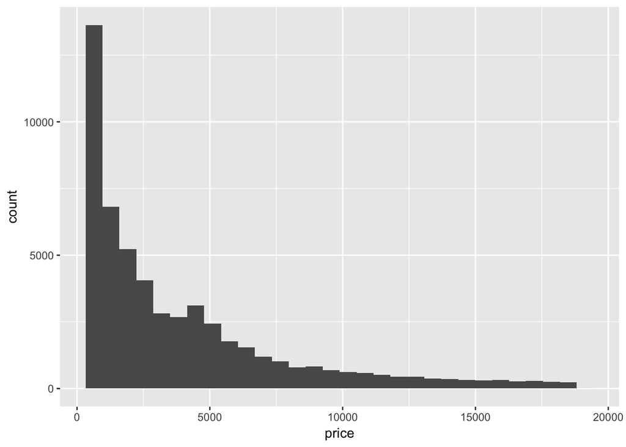

```r
ggplot(diamonds) +
  geom_histogram(mapping = aes(x = price))
```

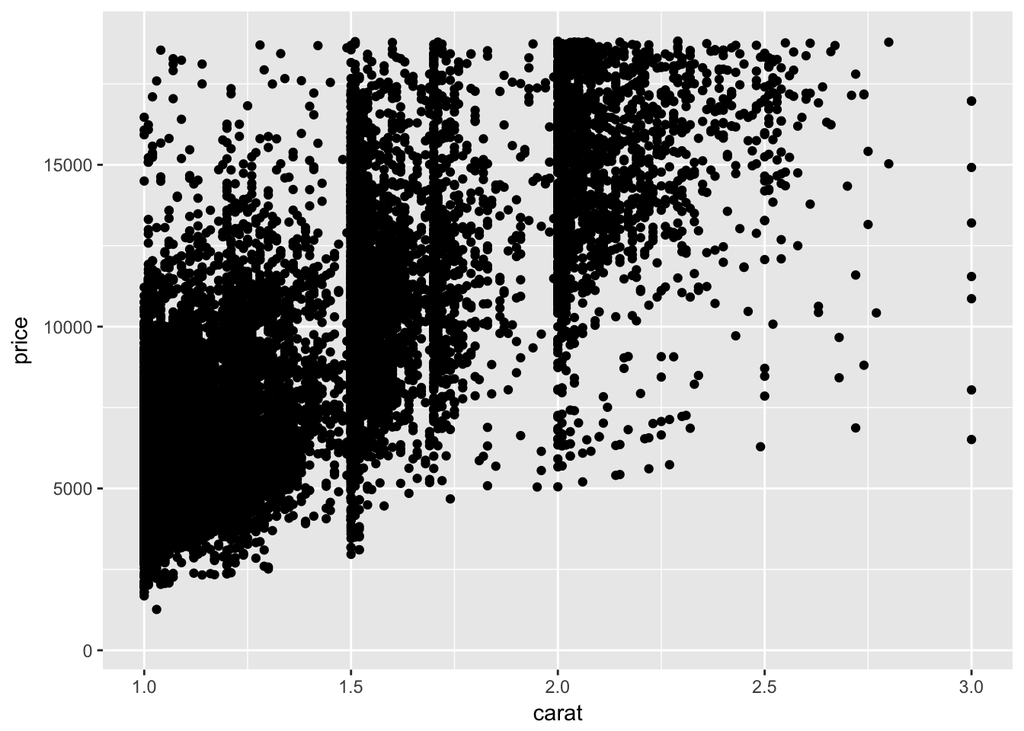

```r
#binwidth unset

ggplot(diamonds, aes(carat, price)) +
  geom_point() +
  xlim(1, 3)
```

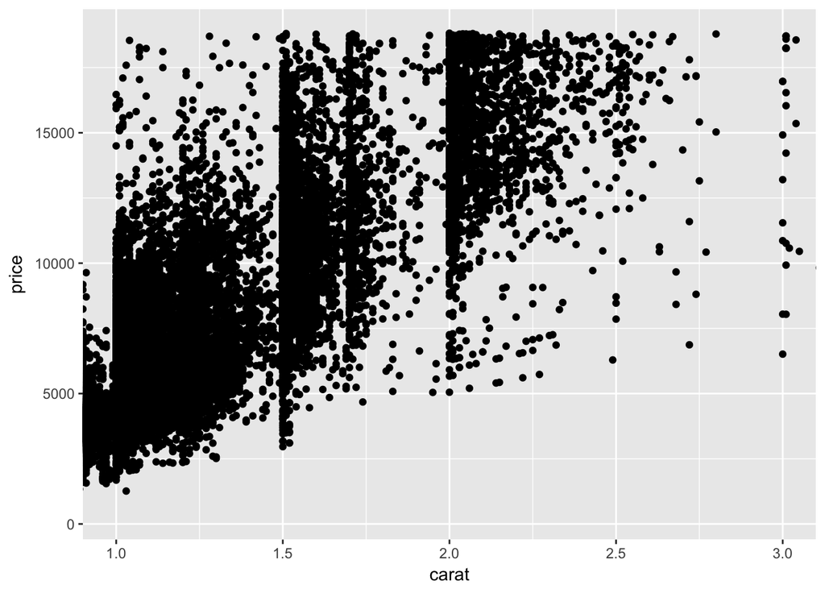

```r
ggplot(diamonds, aes(carat, price)) +
  geom_point() +
  coord_cartesian(xlim = c(1,3))
```

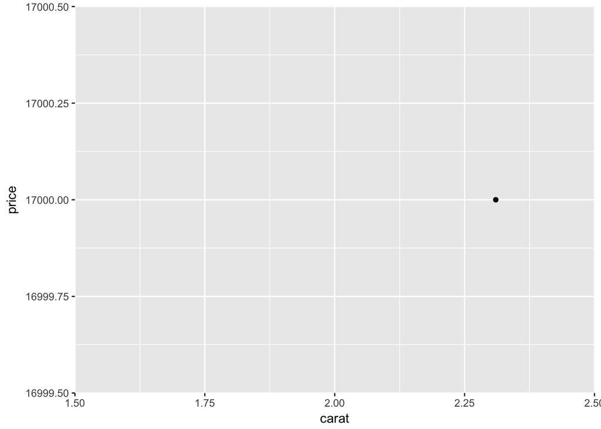

```r
ggplot(diamonds, aes(carat, price)) +
  geom_point() +
  coord_cartesian(xlim = 2, ylim = 17000)
```

```r
#only shows one datapoint at $17000 at 2.3 carats. rest got cut off when zooming in.
```

Leaving binwidth unset defaults to 30 and we see that most diamonds are priced in the lower ranges. Using just geom_point with xlim from 1 to 3 limits the graph to display only datapoints between 1 and 3 carats without y limits, unless we specify. Adding coord_cartesian limits the axes but does not limit datapoints from displaying outside the xlim specification. When zooming, the xlim value get cut off, seen in last graph.

## 1

```r
summary(diamonds)
```

```
##      carat               cut        color        clarity
##  Min.   :0.2000   Fair     : 1610   D: 6775   SI1    :13065
##  1st Qu.:0.4000   Good     : 4906   E: 9797   VS2    :12258
##  Median :0.7000   Very Good:12082   F: 9542   SI2    : 9194
##  Mean   :0.7979   Premium  :13791   G:11292   VS1    : 8171
##  3rd Qu.:1.0400   Ideal    :21551   H: 8304   VVS2   : 5066
##  Max.   :5.0100                     I: 5422   VVS1   : 3655
##                                     J: 2808   (Other): 2531
##      depth           table           price             x
##  Min.   :43.00   Min.   :43.00   Min.   :  326   Min.   : 0.000
##  1st Qu.:61.00   1st Qu.:56.00   1st Qu.:  950   1st Qu.: 4.710
##  Median :61.80   Median :57.00   Median : 2401   Median : 5.700
##  Mean   :61.75   Mean   :57.46   Mean   : 3933   Mean   : 5.731
##  3rd Qu.:62.50   3rd Qu.:59.00   3rd Qu.: 5324   3rd Qu.: 6.540
##  Max.   :79.00   Max.   :95.00   Max.   :18823   Max.   :10.740
##
##        y                z
##  Min.   : 0.000   Min.   : 0.000
##  1st Qu.: 4.720   1st Qu.: 2.910
##  Median : 5.710   Median : 3.530
##  Mean   : 5.735   Mean   : 3.539
##  3rd Qu.: 6.540   3rd Qu.: 4.040
##  Max.   :58.900   Max.   :31.800
##
```

```r
#looks like the diamonds dataset doesn't have missing values...

summary(flights)
```

```
##       year          month             day           dep_time
##  Min.   :2013   Min.   : 1.000   Min.   : 1.00   Min.   :   1
##  1st Qu.:2013   1st Qu.: 4.000   1st Qu.: 8.00   1st Qu.: 907
##  Median :2013   Median : 7.000   Median :16.00   Median :1401
##  Mean   :2013   Mean   : 6.549   Mean   :15.71   Mean   :1349
##  3rd Qu.:2013   3rd Qu.:10.000   3rd Qu.:23.00   3rd Qu.:1744
##  Max.   :2013   Max.   :12.000   Max.   :31.00   Max.   :2400
##                                                  NA's   :8255
##  sched_dep_time   dep_delay          arr_time    sched_arr_time
##  Min.   : 106   Min.   : -43.00   Min.   :   1   Min.   :   1
##  1st Qu.: 906   1st Qu.:  -5.00   1st Qu.:1104   1st Qu.:1124
##  Median :1359   Median :  -2.00   Median :1535   Median :1556
##  Mean   :1344   Mean   :  12.64   Mean   :1502   Mean   :1536
##  3rd Qu.:1729   3rd Qu.:  11.00   3rd Qu.:1940   3rd Qu.:1945
##  Max.   :2359   Max.   :1301.00   Max.   :2400   Max.   :2359
##                 NA's   :8255      NA's   :8713
##    arr_delay          carrier              flight       tailnum
##  Min.   : -86.000   Length:336776      Min.   :   1   Length:336776
##  1st Qu.: -17.000   Class :character   1st Qu.: 553   Class :character
##  Median :  -5.000   Mode  :character   Median :1496   Mode  :character
##  Mean   :   6.895                      Mean   :1972
##  3rd Qu.:  14.000                      3rd Qu.:3465
##  Max.   :1272.000                      Max.   :8500
##  NA's   :9430
##     origin              dest              air_time        distance
##  Length:336776      Length:336776      Min.   : 20.0   Min.   :  17
##  Class :character   Class :character   1st Qu.: 82.0   1st Qu.: 502
##  Mode  :character   Mode  :character   Median :129.0   Median : 872
##                                        Mean   :150.7   Mean   :1040
##                                        3rd Qu.:192.0   3rd Qu.:1389
##                                        Max.   :695.0   Max.   :4983
##                                        NA's   :9430
##       hour           minute        time_hour
##  Min.   : 1.00   Min.   : 0.00   Min.   :2013-01-01 05:00:00
##  1st Qu.: 9.00   1st Qu.: 8.00   1st Qu.:2013-04-04 13:00:00
##  Median :13.00   Median :29.00   Median :2013-07-03 10:00:00
##  Mean   :13.18   Mean   :26.23   Mean   :2013-07-03 05:02:36
##  3rd Qu.:17.00   3rd Qu.:44.00   3rd Qu.:2013-10-01 07:00:00
##  Max.   :23.00   Max.   :59.00   Max.   :2013-12-31 23:00:00
##
```

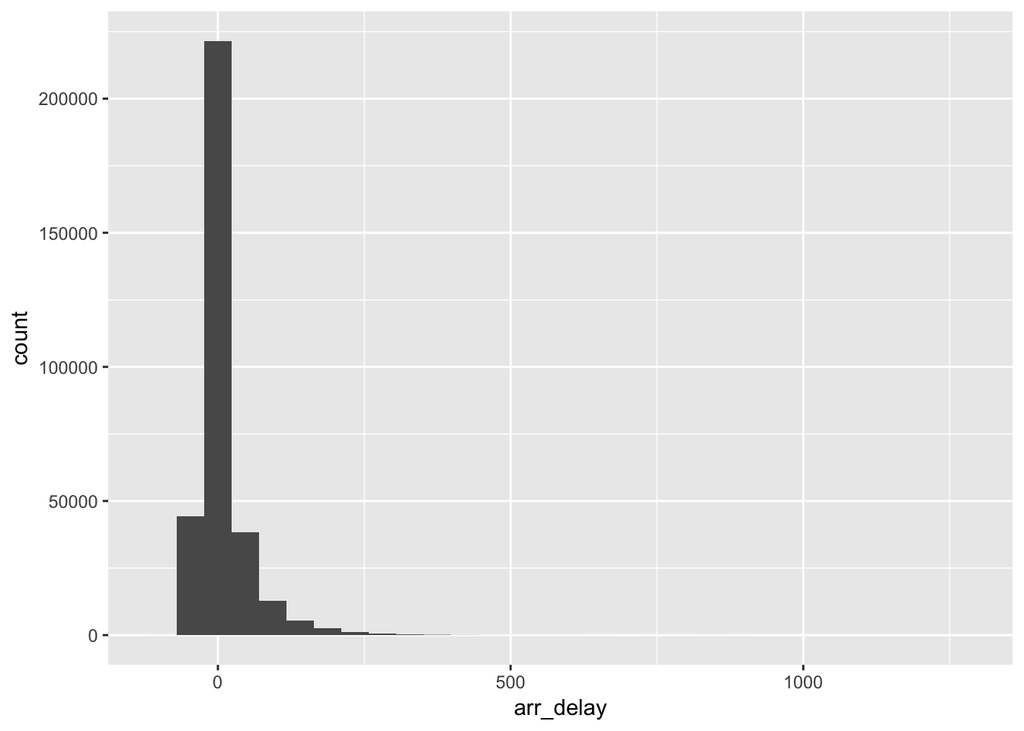

```r
#arr_delay has 9430 missing values

ggplot(flights, aes(arr_delay)) +
  geom_histogram()
```

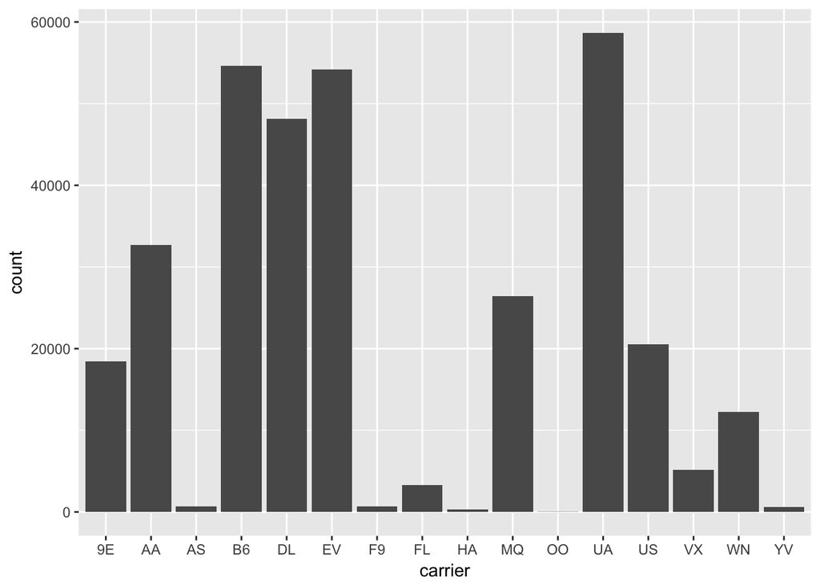

```r
ggplot(flights, aes(carrier)) +
  geom_bar()
```

Using geom_histogram, missing values are dropped. The dropped values match the 9430 displayed by summary. Using geom_bar, the bar chart maps missing values as NA because it can read NA as another categorical value while geom_histogram does not.

## 2

na.rm = TRUE in mean() and sum() drops the NA values before performing functions.

# 1.5

## 1

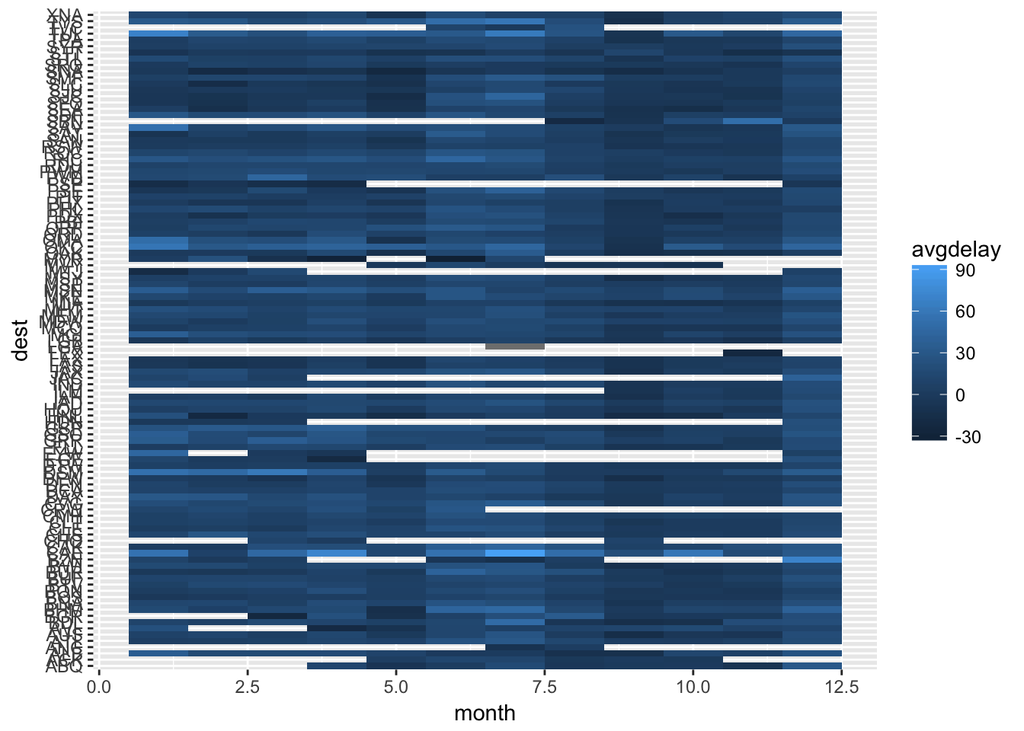

```r
newdf <- flights %>%
  group_by(dest, month) %>%
  summarise(avgdelay = mean(arr_delay, na.rm = TRUE))

ggplot(newdf, mapping = aes(x = month, y = dest)) +
 geom_tile(mapping = aes(fill = avgdelay))
```

Some of the issues with the plot are: - there are too many destinations that it is impossible to see the different destinations on the y axis - the x axis starts with 0 and ends with 12.5 because the units of counting is 2.5 and not 1.

## 2

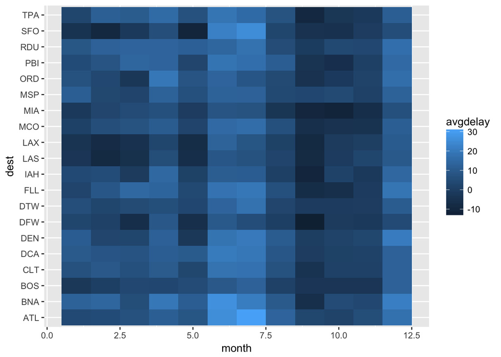

```r
top20dest <- flights %>% count(dest) %>% arrange(desc(n)) %>% head(arrange(desc(n)), n =20)
list20dest <- top20dest$dest

list <- c("ORD", "ATL", "LAX", "BOS", "MCO", "CLT", "SFO", "FLL", "MIA", "DCA", "DTW", "DFW", "RDU", "TPA", "DEN", "IAH", "MSP", "PBI", "BNA", "LAS")

newdf2 <- flights %>%
  filter(dest %in% list) %>%
  group_by(dest, month) %>%
  summarise(avgdelay = mean(arr_delay, na.rm = TRUE))

ggplot(newdf2, mapping = aes(x = month, y = dest)) +
 geom_tile(mapping = aes(fill = avgdelay))
```

I first picked the top 20 most travelled destinations by counting the number of times they appear as destinations. I then used these 20 destinations to graph the plot again so it’s more readable but still relevant.

## 3

# Public Sector Application

## 4

```r
chi.flights_Jan <- read_csv("Jan.csv")
chi.flights_Feb <- read_csv("Feb.csv")
chi.flights_March <- read_csv("March.csv")
chi.flights_April <- read_csv("April.csv")
chi.flights_May <- read_csv("May.csv")
chi.flights_June <- read_csv("June.csv")
chi.flights_July <- read_csv("July.csv")
chi.flights_Aug <- read_csv("Aug.csv")
chi.flights_Sept <- read_csv("Sept.csv")
chi.flights_Oct <- read_csv("Oct.csv")
chi.flights_Nov <- read_csv("Nov.csv")
chi.flights_Dec <- read_csv("Dec.csv")
totflights <- bind_rows(chi.flights_Jan, chi.flights_Feb, chi.flights_March, chi.flights_April, chi.flights_May, chi.flights_June, chi.flights_July, chi.flights_Aug, chi.flights_Sept, chi.flights_Oct, chi.flights_Nov, chi.flights_Dec)

chi <- c("ORD", "MDW")
chiflights <- totflights%>% filter(ORIGIN %in% chi | DEST %in% chi)
#limit sample flights to just ORD or MDW-related flights
```

## 1

```r
chiflights %>%
  group_by(FL_DATE) %>%
  summarise(avg = mean(ARR_DELAY, na.rm = TRUE)) %>%
  arrange(avg)
```

```
## # A tibble: 366 x 2
##       FL_DATE       avg
##        <date>     <dbl>
##  1 2016-01-30 -13.12979
##  2 2016-02-27 -12.82682
##  3 2016-11-24 -12.66502
##  4 2016-02-07 -12.29565
##  5 2016-02-06 -12.12825
##  6 2016-02-01 -11.87330
##  7 2016-02-20 -11.27219
##  8 2016-11-25 -10.88490
##  9 2016-11-05 -10.68798
## 10 2016-09-04 -10.47014
## # ... with 356 more rows
```

```r
#January 30th is the day with lowest average arrival delays.

chiflights %>%
  group_by(FL_DATE) %>%
  mutate(notdelayed = ARR_DELAY <= 15) %>%
  summarise(percnotdelayed = mean(notdelayed, na.rm = TRUE)) %>%
  arrange(desc(percnotdelayed))
```

```
## # A tibble: 366 x 2
##       FL_DATE percnotdelayed
##        <date>          <dbl>
##  1 2016-11-24      0.9684729
##  2 2016-11-25      0.9626100
##  3 2016-09-04      0.9574468
##  4 2016-09-03      0.9535055
##  5 2016-11-05      0.9529164
##  6 2016-02-06      0.9512195
##  7 2016-02-27      0.9506264
##  8 2016-02-01      0.9484902
##  9 2016-01-30      0.9460516
## 10 2016-02-07      0.9434783
## # ... with 356 more rows
```

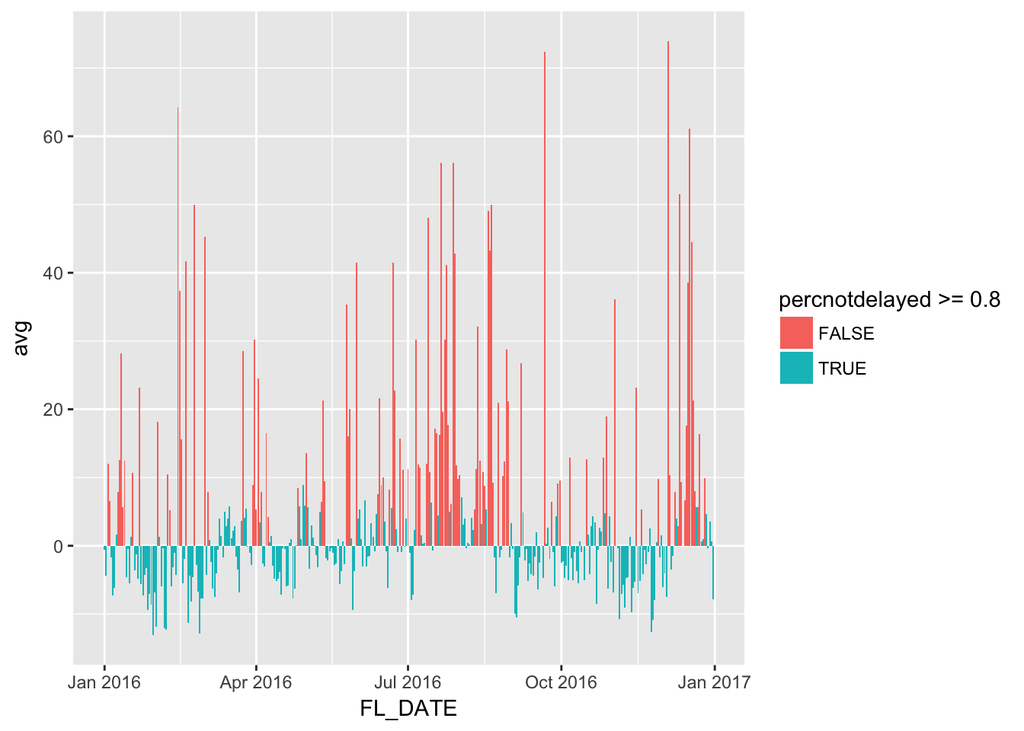

```r
# percent on time (highest on time percentage happens on Nov. 24th at 96.847%)

toplot <- chiflights %>%
  group_by(FL_DATE) %>%
  mutate(notdelayed = ARR_DELAY <= 15) %>%
  summarise(avg = mean(ARR_DELAY, na.rm = TRUE),
            percnotdelayed = mean(notdelayed, na.rm = TRUE))

ggplot(toplot) + geom_col(mapping = aes(x = FL_DATE, y = avg, fill = percnotdelayed >= 0.8))
```

First, we examine all the bars on the graph. The bars indicate the average arrival delays for each day. We can see that the average arrival delays peak between February and March, again between August and September, and reaches the highest peak at the end of the year. The distinction between the orange and blue color show which days have arrival on time percentages above 80%. It makes sense that high on time rates also have low average delays or have earlier arrivals.

## 2

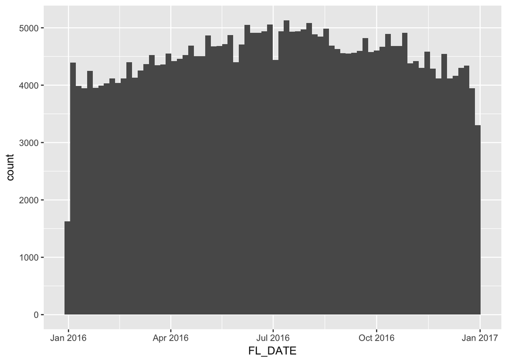

```r
chicagoonly <- chiflights %>% filter(DEST_CITY_NAME == "Chicago, IL")
#only has Chicago destinations
ggplot(chicagoonly) + geom_histogram(mapping = aes(x = FL_DATE), binwidth = 5)
```

Flights to Chicago peak between July and September of 2016. Generally, flights are most common in the summer.

## 3

Based on the results, I would recommend having the conference toward the end of November because it has the highest probability of being on time and has one of the highest numnber of flights. However, since it’s also the same time as Thanksgiving travel season, it does not sound like a good idea to have it near Thanksgiving. So I would really recommend is January 30th because, while it has one of the lowest number of flights to Chicago, it has the shortest length of delays. This recommendation does not take into consideration New Years holidays and whether people want to arrive a day prior to the conference.

```r
toplot <- chiflights %>%
  group_by(FL_DATE) %>%
  summarise(avg = mean(ARR_DELAY, na.rm = TRUE))
```

### 1 basic plot

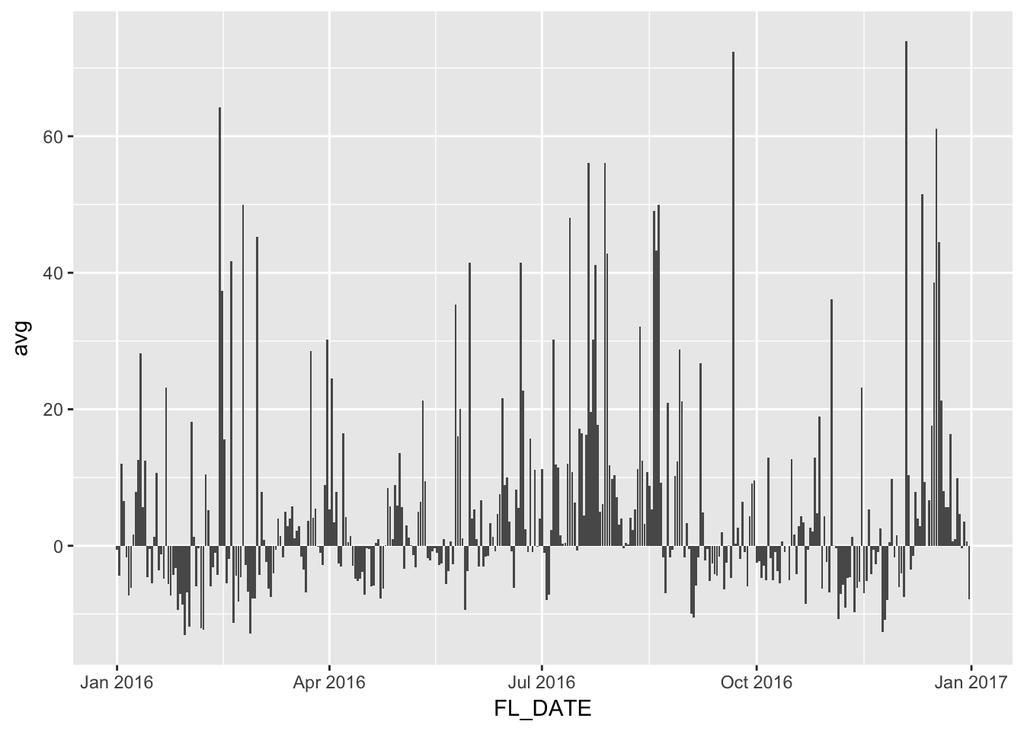

```r
ggplot(toplot) + geom_col(mapping = aes(x = FL_DATE, y = avg))
```

### 2 sophisticated plot

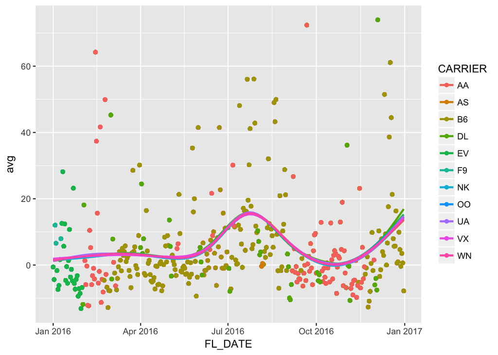

```r
toplot2 <- chiflights %>%
  group_by(FL_DATE) %>%
  mutate(avg = mean(ARR_DELAY, na.rm = TRUE))

ggplot(toplot2,
       mapping = aes(x = FL_DATE, y = avg, color = CARRIER)) +
  geom_point() +
  geom_smooth(se = FALSE)
```

The basic plot just shows average arrival delays by flight date. The sophisticated plot shows the average arrival delay length by flight date and carrier. The color distinctions allow us to see which carriers tend to have more delays around certain dates of the year and the average length of delays that day. I would submit the sophisticated plot to show more information in one graph.

### 3 dataset

Two other pieces of information I would include are flight prices and passenger enplanement. We would want to consider when flights are cheapest and when there is most likely to be tickets/seats available. Prices: https://www.transtats.bts.gov/AIRFARES/ Enplanement: https://www.faa.gov/airports/planning_capacity/passenger_allcargo_stats/passenger/media/cy16-commercial-service-enplanements.pdf

## 4

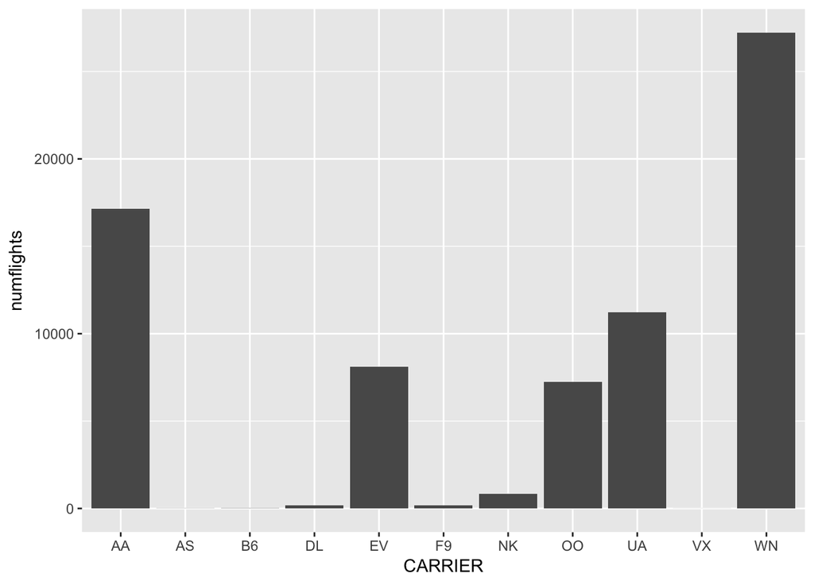

```r
carrierplot <- chiflights %>%
  filter(DEST_CITY_NAME == "Chicago, IL" & FL_DATE == "2016-01-30") %>%
  group_by(CARRIER) %>%
  mutate(avgdelaycarrier = mean(ARR_DELAY, na.rm = TRUE), numflights = n()) %>%
  arrange(avgdelaycarrier)

# simple plot
ggplot(carrierplot) + geom_col(mapping = aes(x = CARRIER, y = numflights))
```

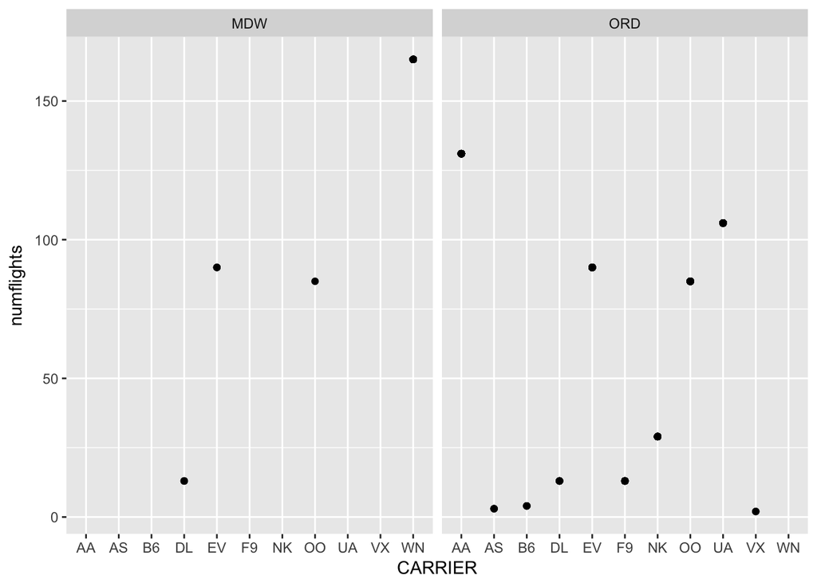

```r
# sophisticated plot
ggplot(carrierplot, mapping = aes(x = CARRIER, y = numflights)) +
  geom_point() +
  facet_wrap(~DEST)
```

## 5

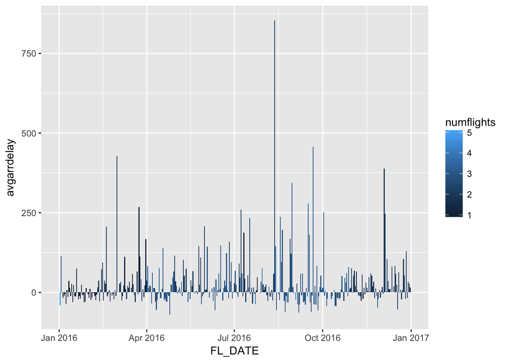

```r
gaplot <- chiflights %>%
  filter(ORIGIN_CITY_NAME == "Savannah, GA" &
           DEST_CITY_NAME == "Chicago, IL") %>%
  group_by(MONTH, DAY_OF_MONTH) %>%
  mutate(avgarrdelay = mean(ARR_DELAY, na.rm = TRUE), numflights = n()) %>%
  arrange(avgarrdelay) %>%
  select(avgarrdelay, numflights, MONTH, DAY_OF_MONTH, everything())

ggplot(gaplot) + geom_col(mapping = aes(x = FL_DATE, y = avgarrdelay, fill = numflights))
```